# Project: Investigate TMDb Movie Dataset

- Introduction
- Data Wrangling
- Exploratory Data Analysis
- Conclusions

## Introduction

This project will be investigating the TMDb movie dataset. The dataset contains information about 10,000 movie titles. Focus of this analysis will be on finding trends in terms of production cost of movie over time across the different genres, and how they relate to success, popularity. The dataset contains key features: "origiginal_title" holds the title for each movie; "genres" is the category each movie; "budget" is the production cost for each movie; "revenue" is amount the amount for each movie grossed; "release_year" is the year each movie was released; "popularity" is the rating for each movie. Quick overview of the dataset indicates 10866 records across 21 columns spanning between year 1960 and 2015.

The questions anaysis will answer are:

#### 2: What period saw significant rise in spending ?

#### 3a: What are the ten most popular genres in the last ten years?

#### 3b: What genre produced most popular movies during the last ten years?

#### 3c: Do popular genres generate high revenue?

```python
# importing packages

import pandas as pd
import numpy as np
import seaborn as sns
import matplotlib.pyplot as plt
%matplotlib inline
```

## Data Wrangling

### General Properties

```python
# loading data
df = pd.read_csv(r'C:\Users\Owner\Downloads\tmdb_movies.csv')
df.head() # preview dataset
```

|  | id | imdb_id | popularity | budget | revenue | original_title | cast | homepage | director | tagline | ... | overview | runtime | genres | production_companies | release_date | vote_count | vote_average | release_year | budget_adj | revenue_adj |
| --- | --- | --- | --- | --- | --- | --- | --- | --- | --- | --- | --- | --- | --- | --- | --- | --- | --- | --- | --- | --- | --- |
| 0 | 135397 | tt0369610 | 32.985763 | 150000000 | 1513528810 | Jurassic World | Chris Pratt\|Bryce Dallas Howard\|Irrfan Khan\|Vi... | http://www.jurassicworld.com/ | Colin Trevorrow | The park is open. | ... | Twenty-two years after the events of Jurassic ... | 124 | Action\|Adventure\|Science Fiction\|Thriller | Universal Studios\|Amblin Entertainment\|Legenda... | 6/9/15 | 5562 | 6.5 | 2015 | 1.379999e+08 | 1.392446e+09 |
| 1 | 76341 | tt1392190 | 28.419936 | 150000000 | 378436354 | Mad Max: Fury Road | Tom Hardy\|Charlize Theron\|Hugh Keays-Byrne\|Nic... | http://www.madmaxmovie.com/ | George Miller | What a Lovely Day. | ... | An apocalyptic story set in the furthest reach... | 120 | Action\|Adventure\|Science Fiction\|Thriller | Village Roadshow Pictures\|Kennedy Miller Produ... | 5/13/15 | 6185 | 7.1 | 2015 | 1.379999e+08 | 3.481613e+08 |
| 2 | 262500 | tt2908446 | 13.112507 | 110000000 | 295238201 | Insurgent | Shailene Woodley\|Theo James\|Kate Winslet\|Ansel... | http://www.thedivergentseries.movie/#insurgent | Robert Schwentke | One Choice Can Destroy You | ... | Beatrice Prior must confront her inner demons ... | 119 | Adventure\|Science Fiction\|Thriller | Summit Entertainment\|Mandeville Films\|Red Wago... | 3/18/15 | 2480 | 6.3 | 2015 | 1.012000e+08 | 2.716190e+08 |
| 3 | 140607 | tt2488496 | 11.173104 | 200000000 | 2068178225 | Star Wars: The Force Awakens | Harrison Ford\|Mark Hamill\|Carrie Fisher\|Adam D... | http://www.starwars.com/films/star-wars-episod... | J.J. Abrams | Every generation has a story. | ... | Thirty years after defeating the Galactic Empi... | 136 | Action\|Adventure\|Science Fiction\|Fantasy | Lucasfilm\|Truenorth Productions\|Bad Robot | 12/15/15 | 5292 | 7.5 | 2015 | 1.839999e+08 | 1.902723e+09 |
| 4 | 168259 | tt2820852 | 9.335014 | 190000000 | 1506249360 | Furious 7 | Vin Diesel\|Paul Walker\|Jason Statham\|Michelle ... | http://www.furious7.com/ | James Wan | Vengeance Hits Home | ... | Deckard Shaw seeks revenge against Dominic Tor... | 137 | Action\|Crime\|Thriller | Universal Pictures\|Original Film\|Media Rights ... | 4/1/15 | 2947 | 7.3 | 2015 | 1.747999e+08 | 1.385749e+09 |

5 rows × 21 columns

Data Assessment

```python
# here lets get more information about the dataset
df.info()
```

```
<class 'pandas.core.frame.DataFrame'>
RangeIndex: 10866 entries, 0 to 10865
Data columns (total 21 columns):
 #   Column                Non-Null Count  Dtype
---  ------                --------------  -----
 0   id                    10866 non-null  int64
 1   imdb_id               10856 non-null  object
 2   popularity            10866 non-null  float64
 3   budget                10866 non-null  int64
 4   revenue               10866 non-null  int64
 5   original_title        10866 non-null  object
 6   cast                  10790 non-null  object
 7   homepage              2936 non-null   object
 8   director              10822 non-null  object
 9   tagline               8042 non-null   object
 10  keywords              9373 non-null   object
 11  overview              10862 non-null  object
 12  runtime               10866 non-null  int64
 13  genres                10843 non-null  object
 14  production_companies  9836 non-null   object
 15  release_date          10866 non-null  object
 16  vote_count            10866 non-null  int64
 17  vote_average          10866 non-null  float64
 18  release_year          10866 non-null  int64
 19  budget_adj            10866 non-null  float64
 20  revenue_adj           10866 non-null  float64
dtypes: float64(4), int64(6), object(11)
memory usage: 1.7+ MB
```

```python
# summary statistics
df.describe()
```

|  | id | popularity | budget | revenue | runtime | vote_count | vote_average | release_year | budget_adj | revenue_adj |
| --- | --- | --- | --- | --- | --- | --- | --- | --- | --- | --- |
| count | 10866.000000 | 10866.000000 | 1.086600e+04 | 1.086600e+04 | 10866.000000 | 10866.000000 | 10866.000000 | 10866.000000 | 1.086600e+04 | 1.086600e+04 |
| mean | 66064.177434 | 0.646441 | 1.462570e+07 | 3.982332e+07 | 102.070863 | 217.389748 | 5.974922 | 2001.322658 | 1.755104e+07 | 5.136436e+07 |
| std | 92130.136561 | 1.000185 | 3.091321e+07 | 1.170035e+08 | 31.381405 | 575.619058 | 0.935142 | 12.812941 | 3.430616e+07 | 1.446325e+08 |
| min | 5.000000 | 0.000065 | 0.000000e+00 | 0.000000e+00 | 0.000000 | 10.000000 | 1.500000 | 1960.000000 | 0.000000e+00 | 0.000000e+00 |
| 25% | 10596.250000 | 0.207583 | 0.000000e+00 | 0.000000e+00 | 90.000000 | 17.000000 | 5.400000 | 1995.000000 | 0.000000e+00 | 0.000000e+00 |
| 50% | 20669.000000 | 0.383856 | 0.000000e+00 | 0.000000e+00 | 99.000000 | 38.000000 | 6.000000 | 2006.000000 | 0.000000e+00 | 0.000000e+00 |
| 75% | 75610.000000 | 0.713817 | 1.500000e+07 | 2.400000e+07 | 111.000000 | 145.750000 | 6.600000 | 2011.000000 | 2.085325e+07 | 3.369710e+07 |
| max | 417859.000000 | 32.985763 | 4.250000e+08 | 2.781506e+09 | 900.000000 | 9767.000000 | 9.200000 | 2015.000000 | 4.250000e+08 | 2.827124e+09 |

```python
# check columns and rows counts
df.shape
```

```
(10866, 21)
```

Based on the shape, we have 10,866 movie titles across 21 columns, which may change once cleaning is applied.

```python
# inspect types for each feature of dataset
df.dtypes
```

```
id                        int64
imdb_id                  object
popularity              float64
budget                    int64
revenue                   int64
original_title           object
cast                     object
homepage                 object
director                 object
tagline                  object
keywords                 object
overview                 object
runtime                   int64
genres                   object
production_companies     object
release_date             object
vote_count                int64
vote_average            float64
release_year              int64
budget_adj              float64
revenue_adj             float64
dtype: object
```

```python
# check for non null unique values of dataset
df.nunique()
```

```
id                      10865
imdb_id                 10855
popularity              10814
budget                    557
revenue                  4702
original_title          10571
cast                    10719
homepage                 2896
director                 5067
tagline                  7997
keywords                 8804
overview                10847
runtime                   247
genres                   2039
production_companies     7445
release_date             5909
vote_count               1289
vote_average               72
release_year               56
budget_adj               2614
revenue_adj              4840
dtype: int64
```

```python
# check for missing values and total count
df.isnull().sum()
```

```
id                         0
imdb_id                   10
popularity                 0
budget                     0
revenue                    0
original_title             0
cast                      76
homepage                7930
director                  44
tagline                 2824
keywords                1493
overview                   4
runtime                    0
genres                    23
production_companies    1030
release_date               0
vote_count                 0
vote_average               0
release_year               0
budget_adj                 0
revenue_adj                0
dtype: int64
```

Some features of the dataset; Homepage, tagline, contain missing or null values. These features are not central to this analysis and will be dropped later in the process.

```python
# check for duplicates rows
df.duplicated().sum()
```

```
1
```

Only one duplicate row present in the dataset!

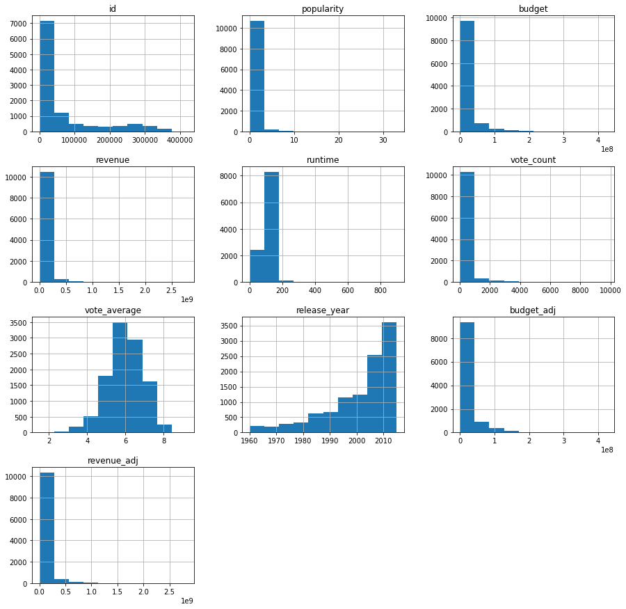

```python
# view distibution data across features
df.hist(figsize=(15, 15))
plt.show()
```

The budget, revenue, popularity are skewed to the right with similar distribution. The release year is skewed to left and shows more movies were made in the 2000s than earlier years.

Overall, initial assessment shows dataset contains considerable anormalies: missing or null values.Most of the affected columns are not central to this analysis and will be address during data cleaning. Only one row has duplicate! Once the irrelevant columns are removed, additional assessment will be performed on tyes and values.

## Data Cleaning

Columns with significant null or missing values are "homepage" 7930, "tagline"2824, "keywords"1493,and "production_companies" 1030.These are not useful columns and will be dropped. Genres has 23 sample as null or missing values. The ratio is negligible considering the total sample size. So, genres will be modified to exclude these missing values.

## Removing Irrelevant Columns

```python
# drop irrelevant columns
df.drop(['id','imdb_id','cast','homepage','director','tagline',\
         'keywords','overview','runtime','production_companies','release_date',\
         'vote_count','vote_average','budget_adj','revenue_adj'], axis=1, inplace=True)
print('dropped columns:  15')
```

```
dropped columns:  15
```

Here, I am dropping all irrelevant columns to decongest dataset and retain needed features.

```python
# view trimmed dataset
df.head()
```

|  | popularity | budget | revenue | original_title | genres | release_year |
| --- | --- | --- | --- | --- | --- | --- |
| 0 | 32.985763 | 150000000 | 1513528810 | Jurassic World | Action\|Adventure\|Science Fiction\|Thriller | 2015 |
| 1 | 28.419936 | 150000000 | 378436354 | Mad Max: Fury Road | Action\|Adventure\|Science Fiction\|Thriller | 2015 |
| 2 | 13.112507 | 110000000 | 295238201 | Insurgent | Adventure\|Science Fiction\|Thriller | 2015 |
| 3 | 11.173104 | 200000000 | 2068178225 | Star Wars: The Force Awakens | Action\|Adventure\|Science Fiction\|Fantasy | 2015 |
| 4 | 9.335014 | 190000000 | 1506249360 | Furious 7 | Action\|Crime\|Thriller | 2015 |

Dataset contains just the features needed for this analysis, however,observing how values for genres are stored; it shows the values are stored as a list of string. This will splitted and extracted later on. For this investigation, I will retain just the first values and consider that as the primary genre for the movie title.

```python
# check the new shape of dataset
df.shape
```

```
(10866, 6)
```

```python
# inspect types for each feature of dataset
df.dtypes
```

```
popularity        float64
budget              int64
revenue             int64
original_title     object
genres             object
release_year        int64
dtype: object
```

Type looks set to go!

```python
# drop rows with any null values in datasets
df.dropna(inplace=True)
```

```python
# confirm null values have been dropped
df.isnull().sum().any()
```

```
False
```

```python
# drop duplicates
df.drop_duplicates(inplace=True)
```

```python
# confirm duplicates are droppred
print(df.duplicated().sum())
```

```
0
```

Nulls, missing, and duplicate values have removed!

### Cleaning The budget and revenue Columns: Removing zeroes:

I did notice zero as value in the budget and revenue columns. This step will address that.

```python
# lets check for budget value that is "0"
print((df['budget']==0).value_counts())
```

```
True     5674
False    5168
Name: budget, dtype: int64
```

```python
# lets check for revenue value that is "0"
print((df['revenue']==0).value_counts())
```

```
True     5993
False    4849
Name: revenue, dtype: int64
```

```python
# cheking for intersection of zero for instance of budget and revenue
((df['budget']==0) & (df['revenue']==0)).value_counts()
```

```
False    6163
True     4679
dtype: int64
```

Conclusions can be drawn that the zeros are due to unavaiable data at the time of collection. Note: "Alvin and the Chipmunks" production was completed on a budget of $60M in 2007, but dataset reflects zero.

```python
# dropping rows where the values for budget, revenue is zero, "0"
df = df.drop(df[(df.budget == 0)].index) # drops zeros from budget
df = df.drop(df[(df.revenue == 0)].index) # drops zero from revenue
```

```python
# confirm rows with "0" budget value are dropped
print((df['budget']==0).value_counts())
```

```
False    3854
Name: budget, dtype: int64
```

```python
# confirm rows with "0" revenue value are dropped
print((df['revenue']==0).value_counts())
```

```
False    3854
Name: revenue, dtype: int64
```

```python
# confirm there are no missing values
df.isnull().sum().any()
```

```
False
```

```python
# check the new shape of dataset
df.info()
```

```
<class 'pandas.core.frame.DataFrame'>
Int64Index: 3854 entries, 0 to 10848
Data columns (total 6 columns):
 #   Column          Non-Null Count  Dtype
---  ------          --------------  -----
 0   popularity      3854 non-null   float64
 1   budget          3854 non-null   int64
 2   revenue         3854 non-null   int64
 3   original_title  3854 non-null   object
 4   genres          3854 non-null   object
 5   release_year    3854 non-null   int64
dtypes: float64(1), int64(3), object(2)
memory usage: 210.8+ KB
```

We now have a clean and tidy dataset with no missing values, zeroes in budget and revenue columns have been removed!

### Splitting the genres column

```python
# first lets split genres and extract the first entry from first index
df.genres = df.genres.str.split("|",expand=True)[0] # splits and extracts the first entry
```

For this analysis, the first value entry of the genres column will be retained as the genre for each movie!

```python
# view the newly splitted genres
df.genres.head()
```

```
0       Action
1       Action
2    Adventure
3       Action
4       Action
Name: genres, dtype: object
```

```python
# creating dataframe for genres sample count
genres_count = df.genres.value_counts() #
genres_count
```

```
Drama              890
Comedy             787
Action             689
Adventure          314
Horror             275
Crime              171
Thriller           160
Fantasy            110
Animation          103
Science Fiction     98
Romance             66
Family              40
Mystery             36
Documentary         32
Music               29
War                 20
History             17
Western             16
TV Movie             1
Name: genres, dtype: int64
```

```python
# summary of genres
genres_count.describe() # view statistics
```

```
count     19.000000
mean     202.842105
std      276.473278
min        1.000000
25%       30.500000
50%       98.000000
75%      223.000000
max      890.000000
Name: genres, dtype: float64
```

The number of movies in each genre are not evenly distributed, though the average is 202.842105.

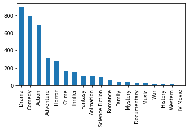

```python
# a visual of sample frequency across genres
df.genres.value_counts().plot(figsize=(6, 3), kind='bar'); # diplaying sample count for each genre
```

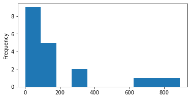

```python
# view of sample distribution across the genres
df.genres.value_counts().plot(figsize=(6, 3),kind='hist',alpha=1);
```

Observation: The distribution of genres sample count is skewed to the right, in line with main data point. Majority of the genres have just under 200 movies. Some genres have higher movie counts, over 600 and up to 890.

Finally, lets rearrange and rename "original_title" to "title" and "release_year" to "year" since there are no conflicting columns.

```python
# rearrange the columns in dataframe
df = df[['original_title','genres','popularity','budget','revenue','release_year']].reset_index(drop=True)
df.head() # preview dataset
```

|  | original_title | genres | popularity | budget | revenue | release_year |
| --- | --- | --- | --- | --- | --- | --- |
| 0 | Jurassic World | Action | 32.985763 | 150000000 | 1513528810 | 2015 |
| 1 | Mad Max: Fury Road | Action | 28.419936 | 150000000 | 378436354 | 2015 |
| 2 | Insurgent | Adventure | 13.112507 | 110000000 | 295238201 | 2015 |
| 3 | Star Wars: The Force Awakens | Action | 11.173104 | 200000000 | 2068178225 | 2015 |
| 4 | Furious 7 | Action | 9.335014 | 190000000 | 1506249360 | 2015 |

```python
# renaming columns; release_year and original_title
df.rename(columns={'original_title':'title', 'release_year':'year'}, inplace=True)
df.head()
```

|  | title | genres | popularity | budget | revenue | year |
| --- | --- | --- | --- | --- | --- | --- |
| 0 | Jurassic World | Action | 32.985763 | 150000000 | 1513528810 | 2015 |
| 1 | Mad Max: Fury Road | Action | 28.419936 | 150000000 | 378436354 | 2015 |
| 2 | Insurgent | Adventure | 13.112507 | 110000000 | 295238201 | 2015 |
| 3 | Star Wars: The Force Awakens | Action | 11.173104 | 200000000 | 2068178225 | 2015 |
| 4 | Furious 7 | Action | 9.335014 | 190000000 | 1506249360 | 2015 |

## Exploratory Data Analysis

### Question 1: How does cost of movie production trend over the years?

```python
# create dataframe for our exploration
cost_df = df.copy() # create dataframe copy
cost_df.head() # preview dataset
```

|  | title | genres | popularity | budget | revenue | year |
| --- | --- | --- | --- | --- | --- | --- |
| 0 | Jurassic World | Action | 32.985763 | 150000000 | 1513528810 | 2015 |
| 1 | Mad Max: Fury Road | Action | 28.419936 | 150000000 | 378436354 | 2015 |
| 2 | Insurgent | Adventure | 13.112507 | 110000000 | 295238201 | 2015 |
| 3 | Star Wars: The Force Awakens | Action | 11.173104 | 200000000 | 2068178225 | 2015 |
| 4 | Furious 7 | Action | 9.335014 | 190000000 | 1506249360 | 2015 |

```python
# check shape of dataframe
cost_df.shape
```

```
(3854, 6)
```

We have 3854 movies with 6 features. Now lets take a look at the summary statistics.

```python
# summary statistics
cost_df.describe()
```

|  | popularity | budget | revenue | year |
| --- | --- | --- | --- | --- |
| count | 3854.000000 | 3.854000e+03 | 3.854000e+03 | 3854.000000 |
| mean | 1.191554 | 3.720370e+07 | 1.076866e+08 | 2001.261028 |
| std | 1.475162 | 4.220822e+07 | 1.765393e+08 | 11.282575 |
| min | 0.001117 | 1.000000e+00 | 2.000000e+00 | 1960.000000 |
| 25% | 0.462368 | 1.000000e+07 | 1.360003e+07 | 1995.000000 |
| 50% | 0.797511 | 2.400000e+07 | 4.480000e+07 | 2004.000000 |
| 75% | 1.368324 | 5.000000e+07 | 1.242125e+08 | 2010.000000 |
| max | 32.985763 | 4.250000e+08 | 2.781506e+09 | 2015.000000 |

```python
# check for $1 budgets
(cost_df['budget']==1).value_counts()
```

```
False    3852
True        2
Name: budget, dtype: int64
```

```python
# expand check for significantly low budgets values
(cost_df['budget']<1000).value_counts()
```

```
False    3832
True       22
Name: budget, dtype: int64
```

```python
# chceck and remove rows with budget less than 1000
excluded_rows = cost_df[(cost_df['budget'] < 200)] # removes 25 rows
excluded_rows.count() # count of records excludes from dataset
```

```
title         22
genres        22
popularity    22
budget        22
revenue       22
year          22
dtype: int64
```

Two movies had budget value of 1, however, we found other movies with low budget values accompanied by enormous revenue that seem untrue. So, a total of 22 records will be excluded from the dataset.The movies excluded here have budget values ranging from 1 to 114.

```python
# view the record excluded
excluded_rows.head()
```

|  | title | genres | popularity | budget | revenue | year |
| --- | --- | --- | --- | --- | --- | --- |
| 503 | Wanted | Action | 0.278387 | 75 | 134 | 2009 |
| 695 | Boy | Drama | 0.028456 | 3 | 43 | 2010 |
| 777 | Angela's Ashes | Drama | 0.352060 | 25 | 13 | 1999 |
| 810 | Lost & Found | Comedy | 0.090186 | 1 | 100 | 1999 |
| 1251 | Love, Wedding, Marriage | Comedy | 0.520430 | 1 | 1378 | 2011 |

The movie "Love, Wedding, Marriage" shows budget has a value of 1 accompanied by a revenue value of 1379; "From Prada to Nada" shows $93 for budget and $2.5m for revenue. So rows with budget value under 1000 will be excluded to minimize noise and impact on distribution. Note: Although 1000 was the limit set, the 22 records excluded from analysis are budgets below 200 in value. From analysis standpoint, thousand makes more meaning than 200, given the range of values we dealing with.

```python
# creating dataframe for movies with budget 1000 and over
budget_df = pd.DataFrame(cost_df[(cost_df['budget']>= 1000)].reset_index(drop=True))
budget_df.head()
```

|  | title | genres | popularity | budget | revenue | year |
| --- | --- | --- | --- | --- | --- | --- |
| 0 | Jurassic World | Action | 32.985763 | 150000000 | 1513528810 | 2015 |
| 1 | Mad Max: Fury Road | Action | 28.419936 | 150000000 | 378436354 | 2015 |
| 2 | Insurgent | Adventure | 13.112507 | 110000000 | 295238201 | 2015 |
| 3 | Star Wars: The Force Awakens | Action | 11.173104 | 200000000 | 2068178225 | 2015 |
| 4 | Furious 7 | Action | 9.335014 | 190000000 | 1506249360 | 2015 |

```python
# summary statistics
budget_df.describe()
```

|  | popularity | budget | revenue | year |
| --- | --- | --- | --- | --- |
| count | 3832.000000 | 3.832000e+03 | 3.832000e+03 | 3832.000000 |
| mean | 1.195952 | 3.741729e+07 | 1.082724e+08 | 2001.273486 |
| std | 1.478069 | 4.223471e+07 | 1.768663e+08 | 11.283691 |
| min | 0.001117 | 6.000000e+03 | 2.000000e+00 | 1960.000000 |
| 25% | 0.464070 | 1.000000e+07 | 1.400000e+07 | 1995.000000 |
| 50% | 0.802644 | 2.400000e+07 | 4.551682e+07 | 2004.000000 |
| 75% | 1.377889 | 5.000000e+07 | 1.249037e+08 | 2010.000000 |
| max | 32.985763 | 4.250000e+08 | 2.781506e+09 | 2015.000000 |

```python
# confirm values less than 1000 removed
(budget_df['budget']<=1000).value_counts()
```

```
False    3832
Name: budget, dtype: int64
```

```python
# check dataset shape after removel
budget_df.shape
```

```
(3832, 6)
```

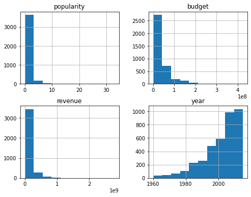

```python
budget_df.hist(figsize=(8, 6));
```

Observing for distribution: There is a non-normal distribution across the features. Popularity, budget, and revenue are positively skewed. So, budget, revenue, and popularity all have more lower values than the do higher values.

Now, lets plot for trend of budget against year.

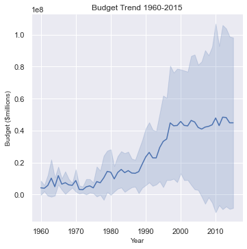

```python
# line plot to view budget over time(year)
plt.figure(figsize = (10,6))
sns.set(style='darkgrid',) # plot backgound as dark
sns.relplot(x='year', y='budget', sort=True, kind='line', ci ='sd',data=budget_df);
plt.title('Budget Trend 1960-2015', fontsize = 12);
plt.xlabel('Year', fontsize = 10)
plt.ylabel('Budget ($millions)', fontsize = 10)
plt.show()
```

```python
# check budget between 1960 and 1990
budget_df.query('year < 1991').mean()['budget']/1000000 # budget in millions
```

```
12.792269735294118
```

```python
# check budget between 1960 and 1990
budget_df.query('year >1991').mean()['budget']/1000000 # budget in millions
```

```
42.66716873501275
```

The plot shows budget trending upward although there were dips during various period. Budgets were much lower in earlier years of the dataset and grew higher in the 2000s. The lowest budget of 6000 occurred in 1960 while the most budget spent, $425m occurred in 2010. Avearge budget is $37.45m. Between 1960 and 1990, the average budget was $12.79m compare to 1991 and 2015 period where average hit $42.67m.

Now, lets examine if there is association between budget and year.

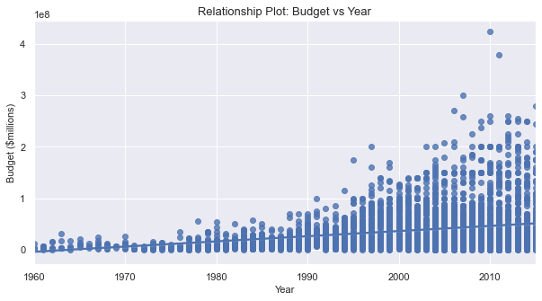

```python
plt.figure(figsize = (10,5))
ax = sns.regplot(x='year', y='budget', data = budget_df)

plt.title('Relationship Plot: Budget vs Year', fontsize = 13)
plt.xlabel('Year', fontsize = 11)
plt.ylabel('Budget ($millions)', fontsize = 11)
plt.show();
```

Budget tend to increase as year progresses. Plot shows there is weak positive association between budget and year.

Overall, budget has been observed to trend upward from 1960 (start-year of dataset) to 2015(current-year of dataset).

### Question 2: What period saw significant rise in spending ?

```python
hi_budget_df = budget_df.copy()
```

```python
# filter movies with budget higher than mean budget
bud_mean =hi_budget_df.budget.mean()
high_bud = hi_budget_df[(hi_budget_df['budget']>bud_mean)].reset_index(drop=True) # filters rows for budget higher than mean budget
high_bud.head() # view datatset
```

|  | title | genres | popularity | budget | revenue | year |
| --- | --- | --- | --- | --- | --- | --- |
| 0 | Jurassic World | Action | 32.985763 | 150000000 | 1513528810 | 2015 |
| 1 | Mad Max: Fury Road | Action | 28.419936 | 150000000 | 378436354 | 2015 |
| 2 | Insurgent | Adventure | 13.112507 | 110000000 | 295238201 | 2015 |
| 3 | Star Wars: The Force Awakens | Action | 11.173104 | 200000000 | 2068178225 | 2015 |
| 4 | Furious 7 | Action | 9.335014 | 190000000 | 1506249360 | 2015 |

```python
# get more info about dataset
high_bud.info()
```

```
<class 'pandas.core.frame.DataFrame'>
RangeIndex: 1287 entries, 0 to 1286
Data columns (total 6 columns):
 #   Column      Non-Null Count  Dtype
---  ------      --------------  -----
 0   title       1287 non-null   object
 1   genres      1287 non-null   object
 2   popularity  1287 non-null   float64
 3   budget      1287 non-null   int64
 4   revenue     1287 non-null   int64
 5   year        1287 non-null   int64
dtypes: float64(1), int64(3), object(2)
memory usage: 60.5+ KB
```

```python
# summary statistics
high_bud.describe()
```

|  | popularity | budget | revenue | year |
| --- | --- | --- | --- | --- |
| count | 1287.000000 | 1.287000e+03 | 1.287000e+03 | 1287.000000 |
| mean | 1.809648 | 8.165310e+07 | 2.237801e+08 | 2004.841492 |
| std | 2.092166 | 4.641295e+07 | 2.489831e+08 | 6.742178 |
| min | 0.031018 | 3.766500e+07 | 1.440000e+02 | 1978.000000 |
| 25% | 0.776294 | 5.000000e+07 | 6.894899e+07 | 2000.000000 |
| 50% | 1.228370 | 6.600000e+07 | 1.492710e+08 | 2005.000000 |
| 75% | 2.084789 | 1.000000e+08 | 2.848884e+08 | 2010.000000 |
| max | 32.985763 | 4.250000e+08 | 2.781506e+09 | 2015.000000 |

We have 1287 movies with budget higher than average budget.

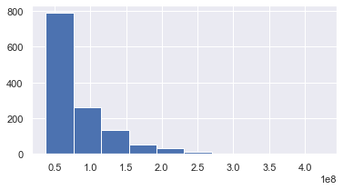

```python
# view distrbution of data
high_bud.budget.hist(figsize=(6, 3));
```

Budget is positively skewed. We have more low movies with low high-budget than we do higher ones.

```python
# create dataframe for
df_period = pd.DataFrame(high_bud.groupby(['year']).sum()['budget'].reset_index())
df_period.head()
```

|  | year | budget |
| --- | --- | --- |
| 0 | 1978 | 55000000 |
| 1 | 1980 | 98000000 |
| 2 | 1982 | 50000000 |
| 3 | 1983 | 79600000 |
| 4 | 1984 | 98000000 |

```python
# calculate mean of high budget
hi_mean = df_period.budget.mean()
```

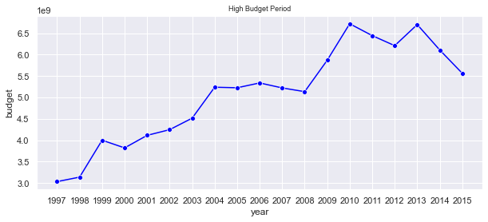

```python
# plot line chart to view revenue reponse to low budget
df_plot = pd.DataFrame(df_period.loc[df_period['budget']> hi_mean].reset_index(drop=True)) # dataframe for budget below  mean budget
data = df_plot
data.year = data.year.astype(str)

fig, ax = plt.subplots(figsize = ( 10 , 4 ))
sns.lineplot(x ='year', y ='budget', marker='o', color='blue', data=data);
plt.title('High Budget Period', fontsize = 9)
```

```python
data.query('year == "2013"')['budget'].max()
```

```
6703000000
```

```python
# checking for highest budget and correspondig year
df_plot.loc[df_plot['budget'].idxmin()]
```

```
year            1997
budget    3035000000
Name: 0, dtype: object
```

Plot above shows big spending on production started from 1997 to current year of dataset. The period between 2000 and 2005, saw budget rose steadily, over $5b and then stabilized between 2005 and 2007. Another sharp rise saw budget hit peak, $6.7b in 2010. Another $6.7b mark attended in 2013. Overall, spending has grown from $3.03b in 1997 to $6.72b in 2010 and a slide from 2013 to 2015.

Lets check association between budget and year:

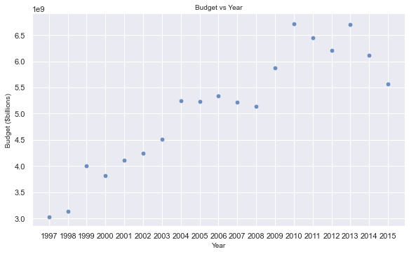

```python
# plotting budget against year

# plot line chart to view revenue reponse to low budget
data= df_plot #= pd.DataFrame(df_period.loc[df_period['budget']> hi_mean].reset_index(drop=False)) # dataframe for budget below  mean budget
data.year = data.year.astype(str)

ax = sns.relplot(x='year', y='budget',data = data,aspect=1.6, alpha = 0.8, s = 40).add_legend()
plt.title('Budget vs Year', fontsize = 10)
plt.xlabel('Year', fontsize = 10)
plt.ylabel('Budget ($billions)', fontsize = 10)
plt.show();
```

Budget tend to increase as year progresses.

Plot above shows big spending on production started from 1997 to current year of dataset, and grew with occassional fall. The period between 2000 and 2005, saw budget rose steadily to slightly over $5b and then stabilized between 2005 and 2007. Another sharp rise saw budget hit peak in 2010. Overall, spending has grown from $3.03b in 1997 to $6.72b in 2010 and dip in 2015.

### Question 3a: What are the most popular genres in the last ten years?

#### Question 3b: What genres produced more popular movies during the last ten years?

#### Question 3c: Do popular genres generate high revenue?

Lets start by preparing dataframe for our exploration.

```python
# create dataframe
genres_df = df.copy()
genres_df.head() # preview dataset
```

|  | title | genres | popularity | budget | revenue | year |
| --- | --- | --- | --- | --- | --- | --- |
| 0 | Jurassic World | Action | 32.985763 | 150000000 | 1513528810 | 2015 |
| 1 | Mad Max: Fury Road | Action | 28.419936 | 150000000 | 378436354 | 2015 |
| 2 | Insurgent | Adventure | 13.112507 | 110000000 | 295238201 | 2015 |
| 3 | Star Wars: The Force Awakens | Action | 11.173104 | 200000000 | 2068178225 | 2015 |
| 4 | Furious 7 | Action | 9.335014 | 190000000 | 1506249360 | 2015 |

```python
genres_df.shape
```

```
(3854, 6)
```

```python
# filter movies made from year 2000 to current
yr_2000_df =genres_df[(genres_df['year']>= 2005)]
yr_2000_df.head()
```

|  | title | genres | popularity | budget | revenue | year |
| --- | --- | --- | --- | --- | --- | --- |
| 0 | Jurassic World | Action | 32.985763 | 150000000 | 1513528810 | 2015 |
| 1 | Mad Max: Fury Road | Action | 28.419936 | 150000000 | 378436354 | 2015 |
| 2 | Insurgent | Adventure | 13.112507 | 110000000 | 295238201 | 2015 |
| 3 | Star Wars: The Force Awakens | Action | 11.173104 | 200000000 | 2068178225 | 2015 |
| 4 | Furious 7 | Action | 9.335014 | 190000000 | 1506249360 | 2015 |

```python
# filter movies with popularity higher than mean popularity
pop_mean = yr_2000_df.popularity.mean() # popularity mean
most_pop = yr_2000_df.loc[(yr_2000_df['popularity']> pop_mean)].reset_index(drop=True) # filter most popular movies
most_pop.head()
```

|  | title | genres | popularity | budget | revenue | year |
| --- | --- | --- | --- | --- | --- | --- |
| 0 | Jurassic World | Action | 32.985763 | 150000000 | 1513528810 | 2015 |
| 1 | Mad Max: Fury Road | Action | 28.419936 | 150000000 | 378436354 | 2015 |
| 2 | Insurgent | Adventure | 13.112507 | 110000000 | 295238201 | 2015 |
| 3 | Star Wars: The Force Awakens | Action | 11.173104 | 200000000 | 2068178225 | 2015 |
| 4 | Furious 7 | Action | 9.335014 | 190000000 | 1506249360 | 2015 |

```python
# check shape of dataset
most_pop.shape
```

```
(559, 6)
```

```python
# summary statistics
most_pop.describe()
```

|  | popularity | budget | revenue | year |
| --- | --- | --- | --- | --- |
| count | 559.000000 | 5.590000e+02 | 5.590000e+02 | 559.000000 |
| mean | 3.083904 | 8.116356e+07 | 2.894244e+08 | 2011.191413 |
| std | 2.641413 | 6.471200e+07 | 3.013069e+08 | 3.156753 |
| min | 1.425344 | 2.000000e+06 | 5.013600e+04 | 2005.000000 |
| 25% | 1.767874 | 3.000000e+07 | 9.556750e+07 | 2009.000000 |
| 50% | 2.345821 | 6.000000e+07 | 1.884416e+08 | 2012.000000 |
| 75% | 3.412650 | 1.255000e+08 | 3.719082e+08 | 2014.000000 |
| max | 32.985763 | 3.800000e+08 | 2.781506e+09 | 2015.000000 |

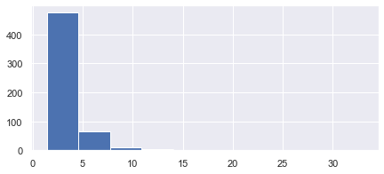

```python
# view distribution with histogram
most_pop.popularity.hist(figsize=(7, 3));
```

Popularity is positively skewed. We have more less-popular movies than we do popular ones.

#### Question 3a: What are the ten most popular genres in the last ten years?

```python
# create dataframe for popular genre
pop_gen = pd.DataFrame(most_pop.groupby('genres')['popularity'].sum().nlargest(n=10).reset_index(drop=False))
```

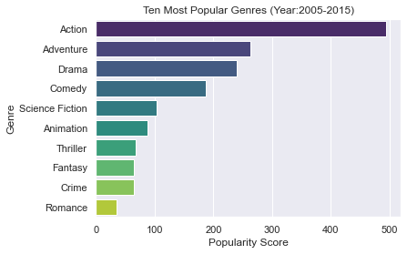

```python
# plot genres with popularity score
data = pop_gen # popularity dataframe

sns.set(style='darkgrid')
ax = sns.barplot( data=data, x='popularity', y='genres', palette='viridis')
plt.title('Ten Most Popular Genres (Year:2005-2015)')
plt.xlabel('Popularity Score')
plt.ylabel('Genre')
```

Above plot shows the 10 most popular genre during the 2005-2015 period with Action leading with a score of 494.32, follwed by Adventure with 262.22 score. At the bottom, we have Crime and Romance with popularity score of 63.69 and 35.58 respectively.

#### Question 3b: What genres produced most popular movies during the last ten years?

```python
# create dataframe for number of movie by genre
movie_count_df =pd.DataFrame(most_pop.groupby('genres')['title'].count().nlargest(n=20).reset_index(drop=False))
movie_count_df.rename(columns={'title':'movie_count'}, inplace=True)
movie_count_df.head()
```

|  | genres | movie_count |
| --- | --- | --- |
| 0 | Action | 129 |
| 1 | Drama | 92 |
| 2 | Comedy | 81 |
| 3 | Adventure | 76 |
| 4 | Animation | 34 |

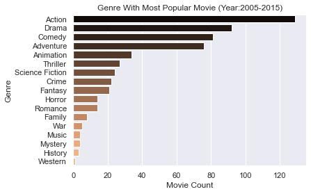

```python
# plot genres with most popular movies
data = movie_count_df

sns.set(style='darkgrid')
ax = sns.barplot( data=data, x='movie_count', y='genres', palette='copper')
plt.title('Genre With Most Popular Movie (Year:2005-2015)')
plt.xlabel('Movie Count')
plt.ylabel('Genre')
```

```python
# check Action count
most_pop.query('genres == "Action"')['title'].count(), most_pop.query('genres == "Western"')['title'].count()
```

```
(129, 1)
```

Action genre has the most popular movies, 129, between 2005 and 2015. Drama, Comedy, Adventure and Animation fall into top 5 category. The least popular genre is Western with one popular movie during the period.

Lets check the association between movie count and popularity score

```python
df1 = movie_count_df.copy()
df2 = pop_gen.copy()
```

```python
# merge movie count and pop_gen dataframes
plot_df  = df1.merge(df2, left_on='genres', right_on='genres', how='inner')
plot_df.head()
```

|  | genres | movie_count | popularity |
| --- | --- | --- | --- |
| 0 | Action | 129 | 494.318704 |
| 1 | Drama | 92 | 239.328392 |
| 2 | Comedy | 81 | 187.642283 |
| 3 | Adventure | 76 | 262.220775 |
| 4 | Animation | 34 | 87.129973 |

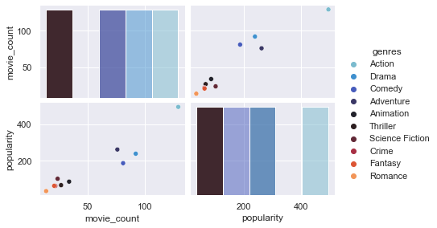

```python
# plot number of movies against popularity score by genre
sns.pairplot(data=plot_df, hue='genres',diag_kind='hist', height=2, aspect=1.5, kind='scatter', palette='icefire');
```

Plot above shows popularity tend increase as movie count increases, indicating a positive association between the two variables. Action, Drama, Comedy, and Adventure tend to have more number of movies and have higher popularity score.

#### Question 3c: Do popular genres generate high revenue?

```python
# create dataframe for genres
df_gen_rev = most_pop.copy()
df_gen_rev.head()
```

|  | title | genres | popularity | budget | revenue | year |
| --- | --- | --- | --- | --- | --- | --- |
| 0 | Jurassic World | Action | 32.985763 | 150000000 | 1513528810 | 2015 |
| 1 | Mad Max: Fury Road | Action | 28.419936 | 150000000 | 378436354 | 2015 |
| 2 | Insurgent | Adventure | 13.112507 | 110000000 | 295238201 | 2015 |
| 3 | Star Wars: The Force Awakens | Action | 11.173104 | 200000000 | 2068178225 | 2015 |
| 4 | Furious 7 | Action | 9.335014 | 190000000 | 1506249360 | 2015 |

```python
# filter movies with revenue higher than mean
h_mean = df_gen_rev.revenue.mean()# find mean
pop_gen_rev = df_gen_rev[(df_gen_rev['revenue']> h_mean)].reset_index(drop=True)
pop_gen_rev.head()
```

|  | title | genres | popularity | budget | revenue | year |
| --- | --- | --- | --- | --- | --- | --- |
| 0 | Jurassic World | Action | 32.985763 | 150000000 | 1513528810 | 2015 |
| 1 | Mad Max: Fury Road | Action | 28.419936 | 150000000 | 378436354 | 2015 |
| 2 | Insurgent | Adventure | 13.112507 | 110000000 | 295238201 | 2015 |
| 3 | Star Wars: The Force Awakens | Action | 11.173104 | 200000000 | 2068178225 | 2015 |
| 4 | Furious 7 | Action | 9.335014 | 190000000 | 1506249360 | 2015 |

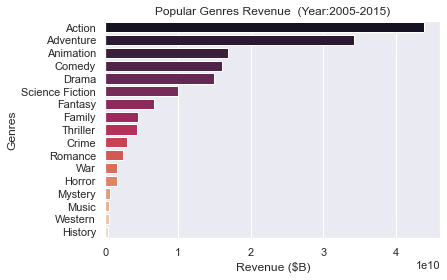

```python
# plotting revenue of popular genres
data2 = pd.DataFrame(most_pop.groupby('genres')['revenue'].sum().nlargest(n=20).reset_index(drop=False))

ax = sns.barplot(data=data2, x='revenue', y='genres', palette='rocket')
plt.title('Popular Genres Revenue  (Year:2005-2015)')
plt.xlabel('Revenue ($B)')
plt.ylabel('Genres')
```

Action genre made $43.9b, the most revenue during 2005-2015 period. Adventure, Animation, Comedy, and Drama are in the top revenue band.

Lets check the relationship between popularity and revenue:

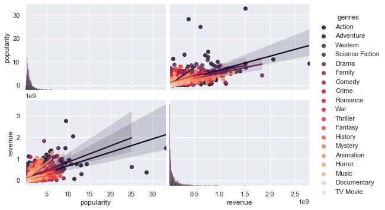

```python
rel_df = genres_df[['genres','popularity','revenue']]
sns.pairplot(data=rel_df, hue='genres',diag_kind='hist', height=2.5, aspect=1.5, kind='reg', palette='rocket');
```

The plot above shows the distribution of popularity and revenue are both skewed to the right. There tend to be more less-popular movies than very popular ones. Movies with lesser revenue are more than the movies with higher revenue. Revenue tend to be positively associated the popularity.

## Conclusions:

The inference drawn from this analysis are not expressed as statistical conclusion as no specific causation have been established. The analysis was performed on dataset which contained some untrue values that resulted in their exclusion, thus, impacting sample size. As a result, the findings are published as observation of the relationship and behavior amongst the variables, where applicable, but not causation. It is important to note that the variables "budget" and "revenue" contained outliers which were not excluded from analysis.

Conclusion 1: How does cost of movie production trend over the years?

The overall view indicated that budget for movies trended upward from the earlier period of the dataset to significantly higher values in the later period. The lowest budget of 6000 occurred in 1960 while the most budget spent, $425m occurred in 2010.

Conclusion 2: What period saw significant rise in spending ?

The analysis observed that significantly higher than average budget was observed in 1997 when budget hit three billion dollars mark and continue to rise to its highest in 2010. Overall, the period between 1997 and 2015 experienced high budget for movie production.

Conclusion 3a: What are the ten most popular genres in the last ten years?

The ten most popular genre during the 2005-2015 period are Action, Adventure, Drama, Comedy, Science Fiction, Animation,Thriller, Fantasy, Crime, and Romance. The genres were measured by their population scores for that period.

Conclusion 3b: What genre produced most popular movies during the last ten years?

Action genre made 129 popular movies between 2005 and 2015. Drama, Comedy, Adventure and Animation fall into top 5 category. The least popular genre is Western with one popular movie during the period. Observation showed that genres with higher number of movies tend to be popular, indicating a positive association between the number of movie made and the popularity score.

Conclusion 3c: Do popular genres generate high revenue?

The analysis observed that genres with higher popularity score acrued more revenue than movies with lower populairty score. There appear to be a positive association between popularity and revenue.